# Background and Context

## Visualizing the Decision Tree

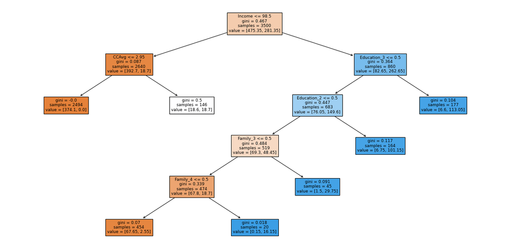

```python
plt.figure(figsize=(20,10))

out = tree.plot_tree(best_model,feature_names=feature_names,filled=True,fontsize=9,node_ids=False,class_names=None)
for o in out:
    arrow = o.arrow_patch
    if arrow is not None:
        arrow.set_edgecolor('black')
        arrow.set_linewidth(1)
plt.show()
```

- This model might be giving the highest recall but a buisness would not be able to use it to actually target the potential customers.

**Creating model with 0.0067 ccp_alpha**

```python
best_model2 = DecisionTreeClassifier(ccp_alpha=0.0067,
                       class_weight={0: 0.15, 1: 0.85}, random_state=1)
best_model2.fit(X_train, y_train)
```

```
DecisionTreeClassifier(ccp_alpha=0.0067, class_weight={0: 0.15, 1: 0.85},
                       random_state=1)
```

```python
get_recall_score(best_model2)
```

```
Recall on training set :  0.9788519637462235
Recall on test set :  0.9530201342281879
```

The results have improved from the initial model and we have got higher recall than the hyperparameter tuned model and generalized decision tree - having comparable performance on training and test set.

## Visualizing the Decision Tree

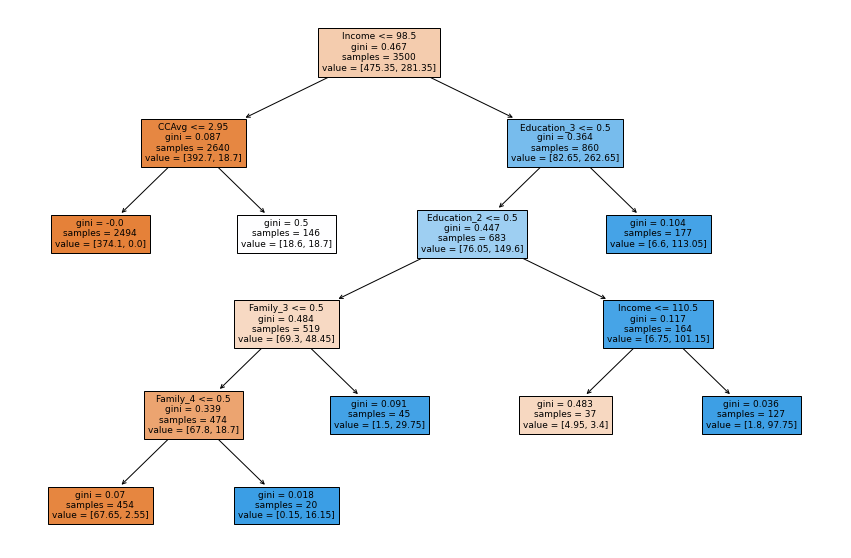

```python
plt.figure(figsize=(15,10))

out = tree.plot_tree(best_model2,feature_names=feature_names,filled=True,fontsize=9,node_ids=False,class_names=None)
for o in out:
    arrow = o.arrow_patch
    if arrow is not None:
        arrow.set_edgecolor('black')
        arrow.set_linewidth(1)
plt.show()
```

```python
# Text report showing the rules of a decision tree -

print(tree.export_text(best_model2,feature_names=feature_names,show_weights=True))
```

```
|--- Income <= 98.50
|   |--- CCAvg <= 2.95
|   |   |--- weights: [374.10, 0.00] class: 0
|   |--- CCAvg >  2.95
|   |   |--- weights: [18.60, 18.70] class: 1
|--- Income >  98.50
|   |--- Education_3 <= 0.50
|   |   |--- Education_2 <= 0.50
|   |   |   |--- Family_3 <= 0.50
|   |   |   |   |--- Family_4 <= 0.50
|   |   |   |   |   |--- weights: [67.65, 2.55] class: 0
|   |   |   |   |--- Family_4 >  0.50
|   |   |   |   |   |--- weights: [0.15, 16.15] class: 1
|   |   |   |--- Family_3 >  0.50
|   |   |   |   |--- weights: [1.50, 29.75] class: 1
|   |   |--- Education_2 >  0.50
|   |   |   |--- Income <= 110.50
|   |   |   |   |--- weights: [4.95, 3.40] class: 0
|   |   |   |--- Income >  110.50
|   |   |   |   |--- weights: [1.80, 97.75] class: 1
|   |--- Education_3 >  0.50
|   |   |--- weights: [6.60, 113.05] class: 1
```

```python
# importance of features in the tree building ( The importance of a feature is computed as the
#(normalized) total reduction of the 'criterion' brought by that feature. It is also known as the Gini importance )

print (pd.DataFrame(best_model2.feature_importances_, columns = ["Imp"], index = X_train.columns).sort_values(by = 'Imp', ascending = False))
```

```
                           Imp
Income                0.642713
Education_2           0.101569
Family_3              0.081044
Family_4              0.078581
CCAvg                 0.055588
Education_3           0.040506
Age                   0.000000
Experience            0.000000
Mortgage              0.000000
Family_2              0.000000
Securities_Account_1  0.000000
CD_Account_1          0.000000
Online_1              0.000000
CreditCard_1          0.000000
```

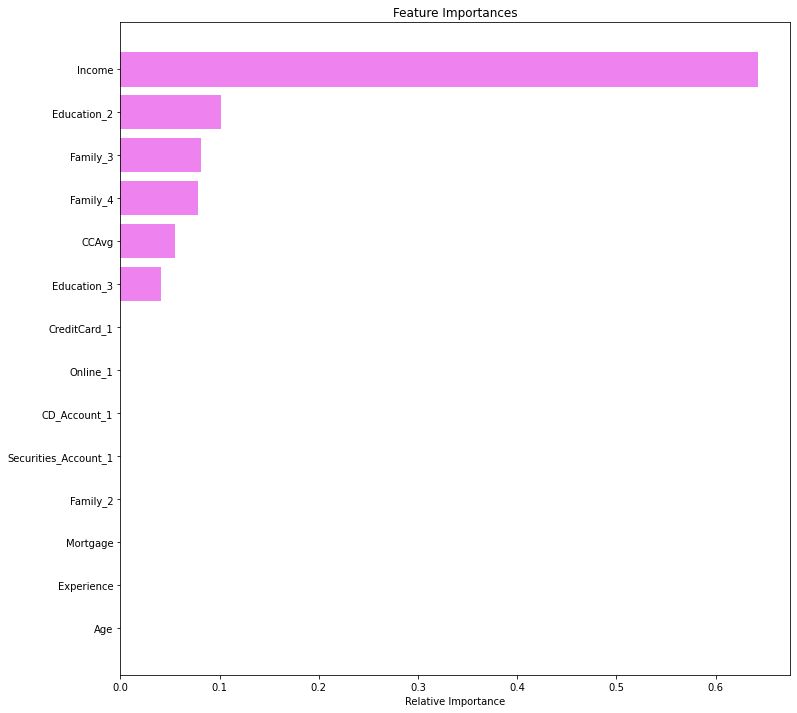

```python
importances = best_model2.feature_importances_
indices = np.argsort(importances)

plt.figure(figsize=(12,12))
plt.title('Feature Importances')
plt.barh(range(len(indices)), importances[indices], color='violet', align='center')
plt.yticks(range(len(indices)), [feature_names[i] for i in indices])
plt.xlabel('Relative Importance')
plt.show()
```

- Income and Education, along with Family size are the top three important features to predict customer sessions contributing to Personal Loan.